# naloga2-Nagelj

13 May 2019

# UVOD

Z zbranimi podatki želimo napovedati ali ima določen pacient prisotno bolezen srca. Za ta klasifikacijski problem bomo primerjali tri različne metode: KNN, logistična regresija in odločitvena drevesa.

# METODOLOGIJA

Pri vsaki metodi bomo najprej na učnih podatkih s pomočjo prečnega preverjanja poiskali najboljšo kombinacijo spremenljivk in parametrov. Za to bomo uporabili metriko accuracy. Nato bomo na testnih podatkih s pomočjo metrike accuracy in auc med sebor primerjali metode.

# PODATKI

Najprej smo preverili ali so prisotne manjkajoče vrednosti, teh ni bilo. Nato smo definiral katere spremenljivke so kategorične in numerične. Naša odvisna spremenljivka oziroma razred je target. Podatke razdelimo na učno (243) in testno množico (60), kjer je 80% podatov v učni. Podatke si ogledamo le na učnem delu podatkov.

```
## Classes 'data.table' and 'data.frame':   243 obs. of  14 variables:
##  $ age     : int  37 41 57 57 56 52 54 48 49 58 ...
##  $ trestbps: int  130 130 120 140 140 172 140 130 130 150 ...
##  $ chol    : int  250 204 354 192 294 199 239 275 266 283 ...
##  $ thalach : int  187 172 163 148 153 162 160 139 171 162 ...
##  $ oldpeak : num  3.5 1.4 0.6 0.4 1.3 0.5 1.2 0.2 0.6 1 ...
##  $ target  : Factor w/ 2 levels "0","1": 2 2 2 2 2 2 2 2 2 2 ...
##  $ sex     : Factor w/ 2 levels "0","1": 2 1 1 2 1 2 2 1 2 1 ...
##  $ cp      : Factor w/ 4 levels "0","1","2","3": 3 2 1 1 2 3 1 3 2 4 ...
##  $ fbs     : Factor w/ 2 levels "0","1": 1 1 1 1 1 2 1 1 1 2 ...
##  $ restecg : Factor w/ 3 levels "0","1","2": 2 1 2 2 1 2 2 2 2 1 ...
##  $ exang   : Factor w/ 2 levels "0","1": 1 1 2 1 1 1 1 1 1 1 ...
##  $ slope   : Factor w/ 3 levels "0","1","2": 1 3 3 2 2 3 3 3 3 3 ...
##  $ ca      : Factor w/ 5 levels "0","1","2","3",..: 1 1 1 1 1 1 1 1 1 1 ...
##  $ thal    : Factor w/ 4 levels "0","1","2","3": 3 3 3 2 3 4 3 3 3 3 ...
##  - attr(*, ".internal.selfref")=<externalptr>
```

```
##          vars   n   mean    sd median trimmed   mad min   max range  skew
## age         1 243  54.49  9.08   55.0   54.58 10.38  29  77.0  48.0 -0.11
## trestbps    2 243 131.68 17.74  130.0  130.43 14.83  94 200.0 106.0  0.73
## chol        3 243 243.74 47.23  240.0  242.26 50.41 126 417.0 291.0  0.42
## thalach     4 243 148.21 23.47  152.0  149.56 23.72  71 202.0 131.0 -0.51
## oldpeak     5 243   0.99  1.11    0.6    0.81  0.89   0   6.2   6.2  1.29
## target*     6 243   1.53  0.50    2.0    1.54  0.00   1   2.0   1.0 -0.14
## sex*        7 243   1.68  0.47    2.0    1.73  0.00   1   2.0   1.0 -0.78
## cp*         8 243   1.97  1.02    2.0    1.88  1.48   1   4.0   3.0  0.45
## fbs*        9 243   1.16  0.37    1.0    1.08  0.00   1   2.0   1.0  1.84
## restecg*   10 243   1.53  0.53    2.0    1.52  0.00   1   3.0   2.0  0.19
## exang*     11 243   1.34  0.47    1.0    1.30  0.00   1   2.0   1.0  0.68
## slope*     12 243   2.40  0.60    2.0    2.45  1.48   1   3.0   2.0 -0.45
## ca*        13 243   1.74  1.03    1.0    1.55  0.00   1   5.0   4.0  1.28
## thal*      14 243   3.31  0.62    3.0    3.36  0.00   1   4.0   3.0 -0.53
##          kurtosis   se
## age         -0.56 0.58
## trestbps     0.99 1.14
## chol         0.45 3.03
## thalach     -0.18 1.51
## oldpeak      1.70 0.07
## target*     -1.99 0.03
## sex*        -1.39 0.03
## cp*         -1.23 0.07
## fbs*         1.39 0.02
## restecg*    -1.27 0.03
## exang*      -1.54 0.03
## slope*      -0.68 0.04
## ca*          0.70 0.07
## thal*        0.38 0.04
```

Imamo 13 atributov, od tega 5 numeričnih in 8 kategoričnih. Za modeliranje kategorični spremenljivk v R-ju je te potrebno definirati kot faktor. Predvsem nam v oči pade oldpeak kjer vidimo da je standardna deviacija precej velika glede na povprečje.

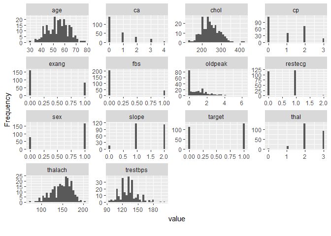

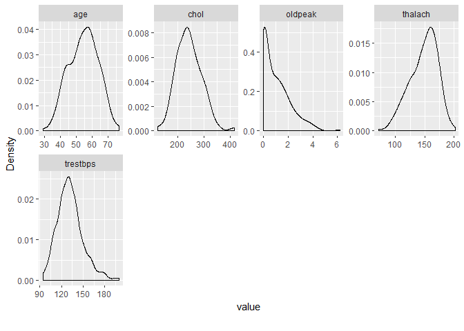

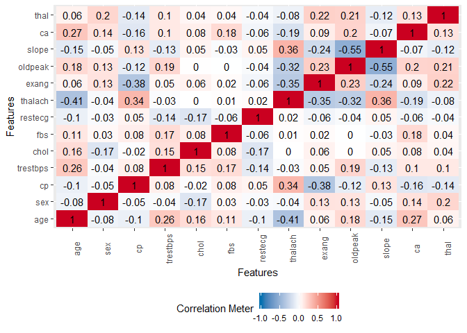

# IZBIRA MODELA

Izbira modela bo potekala v dveh korakih, najprej bomo določili najboljšo kombinacijo spremenljivk za vsako metodo, nato pa na modelih z izbranimi spremenljivkami poiskali najboljše hiperparametre. Naša optimizacija napovednega modela bo temeljila na metriki klasifikacijske točnosti, torej delež pravilno klasicifiranih enot. Za občutek si najprej ogledamo osnovno (baseline) klasifikacijsko točnost, nato pa določimo najboljši napovedni model z iskanjem najboljše kombinacije neodvisnih spremenljivk in hiperparametrov. Pri vseh korakih za boljše ocene uporabimo prečno preverjanje in sicer k-fold cross validation z delitvijo na 10 delov. Torej na 9 delih model naučimo in nato zadnjem, neuporabljenem delu ocenimo točnost modela. Odločil sem se, da bom pri modelu KNN dodatno gledal hiperparameter števila sosedov k, pri klasifikacijskih drevesih pa hiperparameter maksimalne globine. Vsi številčni podatki v modelih so standarizirani.

## Spremenljivke

Za izbiro nabora spremenljivk obstajata dve skupini metod: wrapper in filter. Wrapper metode vrednotijo napovedni model z različnimi kombinacijami spremenljivk in s tem maksimizirajo model glede na določeno metriko (recursive feature elimination, genetic algorithms). Filter metode pa ocenijo relevantnost posameznih spremenljivk brez napovednega modela na podlagi izbranih kriterijev (univariatni filtri). Saj je naš cilj izbrati čimbolj točen napovedni model, se bomo poslužili prve metode. Želel sem preverjati obe metodi backwards selection in genetski algoritem, vendar je moja implementacija trajala predolgo.

### Backwards selection

Metoda deluje tako, da najprej v model vključimo vse spremenljivke, katere rangiramo po pomembnosti za model. Ob vsaki iteraciji je v naslednjem modelu vključenih le k najboljše rangiranih spremenljivk. Ta model zgradimo ponovno in ocenimo njegovo točnost. Postopek ponovimo dokler ne najdemo najboljše kombinacije spremenljivk.

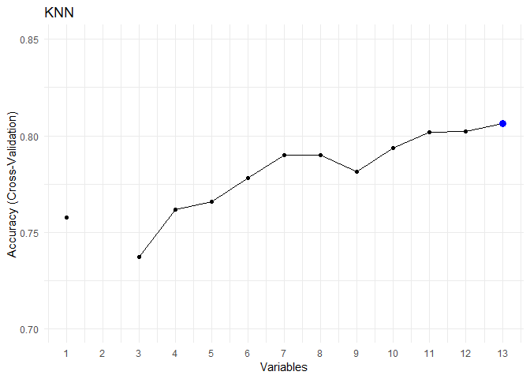

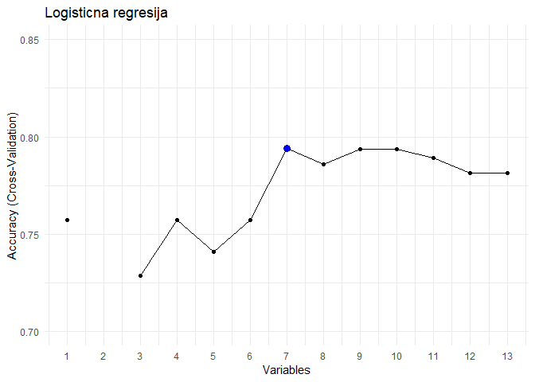

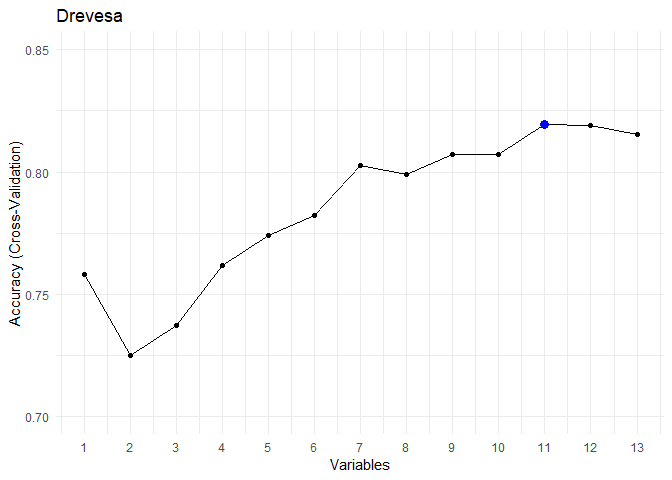

```
##                                                                            Formula
## 1: target~thal+cp+oldpeak+ca+sex+thalach+age+slope+exang+chol+restecg+trestbps+fbs
## 2:                                     target~thal+cp+oldpeak+ca+sex+thalach+exang
## 3:              target~thal+cp+oldpeak+ca+sex+thalach+age+exang+slope+chol+restecg
##    Variables  Accuracy AccuracySD Method
## 1:        13 0.8063333 0.08119782    knn
## 2:         7 0.7941667 0.07789772    glm
## 3:        11 0.8193333 0.07970703 rpart2
```

Vidimo, da so v vseh treh modelih prisotne spremenljivke thal, cp, oldpeak, ca, sex, thalach in exang. Točnosti modelov z izbranimi spremenljvikami so med seboj zelo blizu, intervali zaupanaj se med seboj pokrivajo.

## Hiperparametri

Za KNN in klasifikacijsko drevo s prečnim preverjanje izberemo še primerne hiperparametre.

```
##     Method Parameter  Accuracy     Kappa AccuracySD   KappaSD
##  1:    knn         5 0.7650000 0.5268678 0.08732655 0.1760759
##  2:    knn         7 0.7959167 0.5885502 0.08728425 0.1752673
##  3:    knn         9 0.8192500 0.6362506 0.08429958 0.1693000
##  4:    knn        11 0.8082500 0.6140700 0.08216876 0.1648113
##  5:    knn        13 0.8091000 0.6156500 0.07956970 0.1600707
##  6:    knn        15 0.8083500 0.6134960 0.07925633 0.1603154
##  7:    knn        17 0.8120000 0.6206884 0.08147180 0.1647130
##  8:    knn        19 0.8099667 0.6161918 0.07838507 0.1586700
##  9:    knn        21 0.8110833 0.6180713 0.07880931 0.1599481
## 10:    knn        23 0.8098333 0.6157635 0.07942431 0.1608904
## 11:    glm      none 0.8073833 0.6104674 0.08215915 0.1667360
## 12: rpart2         1 0.7615500 0.5202824 0.08104268 0.1629046
## 13: rpart2         4 0.7868500 0.5692973 0.07345028 0.1478197
## 14: rpart2         6 0.8016333 0.6011155 0.07771967 0.1564624
```

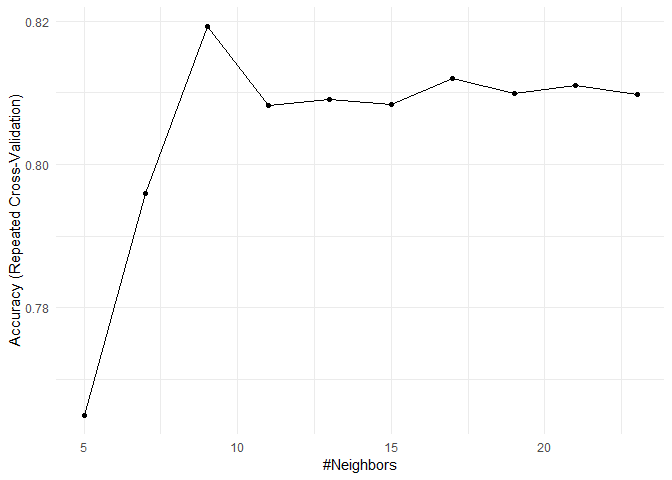

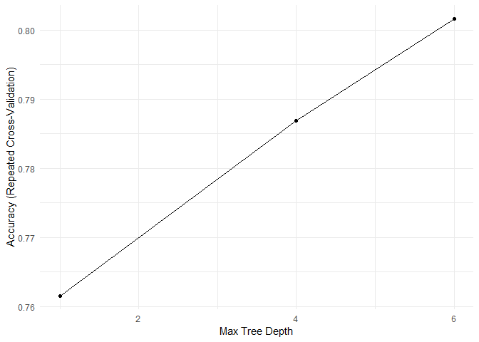

Pri KNN izberemo število sosedov 9, pri klasifikacijskem drevesu pa maksimalno globino 6. Odločili smo se da večjih parametrov ob tem času v izogib preprileganja ne bomo uporabili.

## Končni model

Končni modeli z klasifikacijskimi točnostmi in hiperparametri so naslednji:

```
##    Method Parameter  Accuracy     Kappa AccuracySD   KappaSD
## 1:    knn         9 0.8192500 0.6362506 0.08429958 0.1693000
## 2:    glm      none 0.8073833 0.6104674 0.08215915 0.1667360
## 3: rpart2         6 0.8016333 0.6011155 0.07771967 0.1564624
```

Klasifikacijska drevesa so zelo priročna tudi z vidika vizualizacije modela.

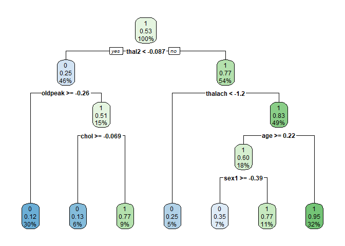

# VREDNOTENJE MODELA

Točnost ocenimo še na testnih podatkih.

## KNN

```
##       Accuracy  AccuracyLower  AccuracyUpper   AccuracyNull AccuracyPValue
##          0.867          0.754          0.941          0.583          0.000
```

```
##       AUC Precision    Recall         F
##  0.743588  0.840000  0.840000  0.840000
```

## Logistična regresija

```
##       Accuracy  AccuracyLower  AccuracyUpper   AccuracyNull AccuracyPValue
##          0.883          0.774          0.952          0.583          0.000
```

```
##       AUC Precision    Recall         F
## 0.9196792 0.8750000 0.8400000 0.8571429
```

## Odločitveno drevo

```
##       Accuracy  AccuracyLower  AccuracyUpper   AccuracyNull AccuracyPValue
##          0.683          0.550          0.797          0.583          0.073
```

```
##       AUC Precision    Recall         F
## 0.2671695 0.6000000 0.7200000 0.6545455
```

Vidimo da model logistične regresije izmed vseh deluje najbolje na testnih podatkih, med tem ko je odločitveno drevo preveč preprilegano na učnih podatkih. Odločili bi se za model z logistično regresijo, saj je boljši tudi od modela KNN tako pri metriki klasifikacijska točnost in AUC. Vidimo, da je AUC katastrofalno slab.

## POMEMBNOST SPREMENLJIVK

Sedaj smo izbrali model, informativno lahko pogledamo še katere spremenljivke so najbolj pomembne. To bi lahko storili že v fazi izbire spremenljivk, vendar je ta informacija bolj vezana na vsebinsko interpretacijo (na žalost nimamo domenskega znanja).

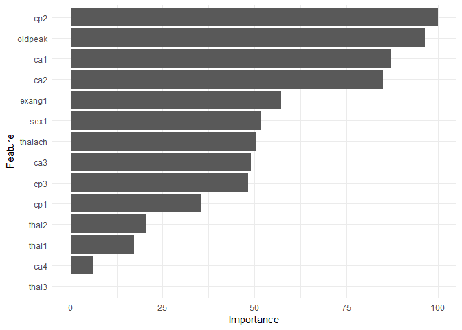